# Likevektsarealkriteriet - Equal Area Criterion

Likevektsaralkriteriet, bedre kjent som Equal Area Criterion (EAC), heretter EAC, er en grafisk metode som gjør det mulig å avgjøre transient stabilitet for et system modellert som SMIB, utifra et simplet kriterie uten å løse komplekse svingeligninger numerisk. EAC avgjør om et system klarer å hente seg inn etter en større forstyrrelse, førstesvingstabilitet, og bevare synkronismen. Klarer ikke systemet å hente seg inn etter første sving, er systemet ustabilt og generatoren faller ut av synkronisme.

### Svingeligningen

Vi betrakter svingeligningen.

$$ M \frac{d^2\delta}{dt^2} = Pa $$

Vi vet at $M = \frac{H}{\pi f} \quad \text{ved per unit}$

$$ \frac{H}{\pi f} \frac{d^2\delta}{dt^2} = Pa $$

Siden H, og f er konstanter, ser vi på når den (andre)deriverte av rotorvinkelen er null. Fra dette definerer vi følgende kriterie for stabilitet; Systemet er stabilt hvis over tid (1 sekund er tilstrekkelig):

$$ \frac{d\delta}{dt} = 0$$

og ustabilt om:

$$ \frac{d\delta}{dt} > 0$$

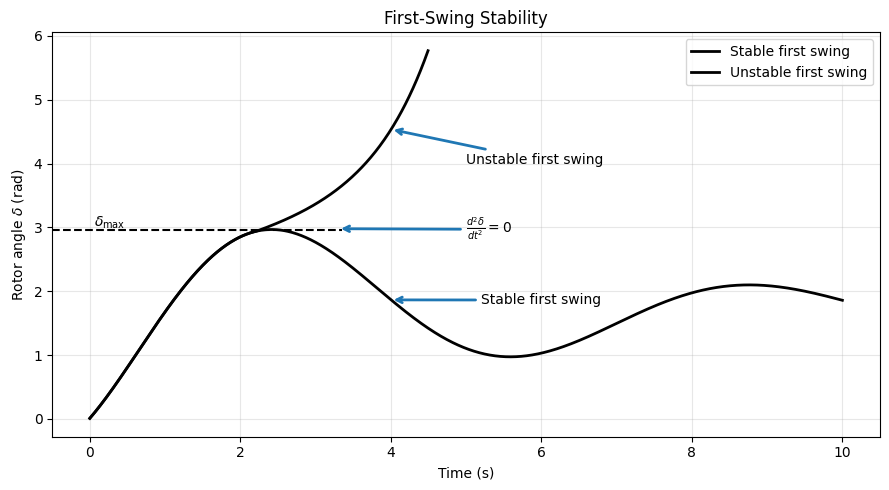

## Modifiserer svingeligningen

Vi tar utgangspunkt i svingeligningen for å omgjøre den til en enkel applikerbar form til å avgjøre stabilitet.

$$ \frac{H}{\pi f} \frac{d^2\delta}{dt^2} = Pa $$

og ser på $\frac{d^2\delta}{dt^2}$:

$$ \frac{d^2\delta}{dt^2} = \frac{\pi f}{H} P_a $$

Vi multipliserer begge sider med $\big(2\frac{d\delta}{dt}\big)$:

$$ \big(2\frac{d\delta}{dt}\big)\frac{d^2\delta}{dt^2} = \big(2\frac{d\delta}{dt}\big)\frac{\pi f}{H} P_a $$

Gjenkjenner kjerneregelen når u er satt til $\frac{d\delta}{dt}$

$$ \frac{d}{dt}\bigg(\bigg[\frac{d\delta}{dt}\bigg]^2\bigg) = \big(2\frac{d\delta}{dt}\big)\frac{\pi f}{H} P_a $$

Gnager med dt på hver side:

$$ \frac{d}{dt}\bigg(\bigg[\frac{d\delta}{dt}\bigg]^2\bigg)\cdot dt = \big(2\frac{d\delta}{dt}\big)\cdot dt\frac{\pi f}{H} P_a $$

Integrerer

$$ \bigg(\frac{d\delta}{dt}^2\bigg) = \frac{2\pi f}{H}\int_{\delta_0}^{\delta_{max}} P_a d\delta $$

eller

$$ \frac{d\delta}{dt} = \sqrt{\frac{2\pi f}{H}\int_{\delta_0}^{\delta_{max}} P_a d\delta} $$

## Evalueres ved 0

Evaluerer uttrykket ved 0

$$ \sqrt{\frac{2\pi f}{H}\int_{\delta_0}^{\delta_{max}} P_a d\delta} = 0 $$

eller integralet

$$ \int_{\delta_0}^{\delta_{max}} P_a d\delta = 0 $$

### Likearealkriteriet

Stabilitetsbetingelsen kan uttrykkes slik: Systemet er stabilt dersom arealet under kurven for akselererende effekt $P_a$ som funksjon av rotorvinkelen $\delta$ blir null ved en bestemt verdi av $\delta$.

Med andre ord må det positive arealet (akselerasjonsarealet) være lik det negative arealet (deakselerasjonsarealet). Derfor kalles dette **likearealkriteriet** (*equal area criterion*) for stabilitet.

Etter en forstyrrelse vil generatoren først akselerere slik at rotorvinkelen $\delta$ øker. Arealet

$$ A_1 = \int P_a \, d\delta $$

representerer den kinetiske energien som lagres i rotoren under akselerasjonen.

For at systemet skal forbli stabilt, må denne energien senere fjernes gjennom en periode med negativ akselererende effekt ($P_a < 0$). Dette gir et deakselerasjonsareal

$$ A_2 = \int (-P_a)\, d\delta . $$

Første sving er stabil dersom

$$ A_1 = A_2 . $$

Når de to arealene er like store, blir rotorhastigheten igjen lik synkronhastigheten, og maskinen forblir i synkronisme med nettet.

Likt areal-kriteriet kan derfor oppsummeres som

$$ \int_{\delta_0}^{\delta_c} P_a \, d\delta = \int_{\delta_c}^{\delta_{\max}} (-P_a)\, d\delta , $$

eller ekvivalent

$$ \int_{\delta_0}^{\delta_{\max}} P_a \, d\delta = 0. $$

Dette er grunnlaget for **likearealkriteriet** (*equal area criterion*) ved analyse av transient stabilitet.

```
δ0     = 30.00°
δcr    = 79.56°
δmax   = 150.00°
A1     = 0.432510
A2     = 0.432510
```

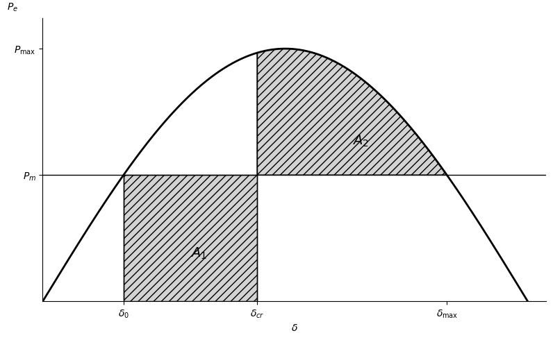

## Utledning av kritisk utkoblingsvinkel

Akselerasjonsarealet er

$$ A_1 = \int_{\delta_0}^{\delta_{cr}} P_m \, d\delta = P_m(\delta_{cr}-\delta_0) $$

Retardasjonsarealet er

$$ A_2 = \int_{\delta_{cr}}^{\delta_{\max}} \left(P_{\max}\sin\delta-P_m\right)d\delta $$

Integrerer leddvis:

$$ A_2 = P_{\max}\int_{\delta_{cr}}^{\delta_{\max}} \sin\delta \, d\delta - P_m\int_{\delta_{cr}}^{\delta_{\max}} d\delta $$

For første integral:

$$ \int \sin\delta\,d\delta = -\cos\delta $$

slik at

$$ P_{\max} \Big[-\cos\delta\Big]_{\delta_{cr}}^{\delta_{\max}} = P_{\max} \left( \cos\delta_{cr} - \cos\delta_{\max} \right) $$

For det andre integralet:

$$ \int d\delta = \delta $$

slik at

$$ P_m \Big[\delta\Big]_{\delta_{cr}}^{\delta_{\max}} = P_m \left( \delta_{\max} - \delta_{cr} \right) $$

Dermed blir

$$ A_2 = P_{\max} \left( \cos\delta_{cr} - \cos\delta_{\max} \right) - P_m \left( \delta_{\max} - \delta_{cr} \right) $$

Likearealkriteriet krever at

$$ A_1=A_2. $$

Setter inn uttrykkene for $A_1$ og $A_2$:

$$ P_m(\delta_{cr}-\delta_0) = P_{\max} \left( \cos\delta_{cr} - \cos\delta_{\max} \right) - P_m \left( \delta_{\max} - \delta_{cr} \right) $$

Utvider høyresiden:

$$ P_m\delta_{cr} - P_m\delta_0 = P_{\max} \left( \cos\delta_{cr} - \cos\delta_{\max} \right) - P_m\delta_{\max} + P_m\delta_{cr} $$

Leddet $P_m\delta_{cr}$ finnes på begge sider og kanselleres:

$$ -P_m\delta_0 = P_{\max} \left( \cos\delta_{cr} - \cos\delta_{\max} \right) - P_m\delta_{\max} $$

Flytter $P_m\delta_{\max}$ til venstre:

$$ P_m \left( \delta_{\max} - \delta_0 \right) = P_{\max} \left( \cos\delta_{cr} - \cos\delta_{\max} \right) $$

Dividerer med $P_{\max}$:

$$ \frac{P_m}{P_{\max}} \left( \delta_{\max} - \delta_0 \right) = \cos\delta_{cr} - \cos\delta_{\max} $$

og løser for $\cos\delta_{cr}$:

$$ \boxed{ \cos\delta_{cr} = \frac{P_m}{P_{\max}} \left( \delta_{\max} - \delta_0 \right) + \cos\delta_{\max} } $$

For tilfellet med en terminalkortslutning hvor

$$ P_e=0 $$

under feilen, er

$$ P_m=P_{\max}\sin\delta_0 $$

og

$$ \delta_{\max} = \pi-\delta_0. $$

Setter vi dette inn, får vi

$$ \cos\delta_{cr} = \sin\delta_0 \left( \pi-2\delta_0 \right) - \cos\delta_0 $$

slik at

$$ \boxed{ \delta_{cr} = \cos^{-1} \left[ (\pi-2\delta_0)\sin\delta_0 - \cos\delta_0 \right] } $$

Alle vinkler i denne formelen må uttrykkes i **radianer**.

## Kritisk utkoblingstid

Svingligningen kan skrives som

$$ \frac{H}{\pi f} \frac{d^2\delta}{dt^2} = P_m. $$

Dermed blir akselerasjonen konstant:

$$ \frac{d^2\delta}{dt^2} = \frac{\pi f}{H}P_m. $$

Integrasjon med

$$ \left.\frac{d\delta}{dt}\right|_{t=0}=0 $$

gir

$$ \delta(t) = \delta_0 + \frac{1}{2} \frac{\pi f}{H} P_m t^2. $$

Når

$$ \delta=\delta_{cr}, $$

oppnås den kritiske utkoblingstiden

$$ \boxed{ t_{cr} = \sqrt{ \frac{2H}{\pi f P_m} (\delta_{cr}-\delta_0) } } $$

hvor alle vinkler må uttrykkes i radianer.

```python
import numpy as np

def critical_clearing(Pm, Pmax, H, f=50):
    """
    Kritisk utkoblingsvinkel og kritisk utkoblingstid
    for tilfellet Pe = 0 under feilen.
    """

    delta0 = np.arcsin(Pm / Pmax)

    delta_cr = np.arccos(
        (np.pi - 2 * delta0) * np.sin(delta0)
        - np.cos(delta0)
    )

    t_cr = np.sqrt(
        (2 * H / (np.pi * f * Pm))
        * (delta_cr - delta0)
    )

    return delta0, delta_cr, t_cr
```

```python
# Eksempel
delta0, delta_cr, t_cr = critical_clearing(
    Pm=1.0,
    Pmax=2.10,
    H=5.0,
    f=50
)

print(f"δ0  = {np.degrees(delta0):.2f}°")
print(f"δcr = {np.degrees(delta_cr):.2f}°")
print(f"tcr = {t_cr:.4f} s")
```

```
δ0  = 28.44°
δcr = 81.72°
tcr = 0.2433 s
```

# Likearealkriteriet for en ikke-null feilkurve

Dette er utledningen av likearealkriteriet for en ikke-null feilkurve $P_{e,II}$, i motsetning til det tidligere tilfellet hvor $P_e=0$ under feilen.

[figure not shown]

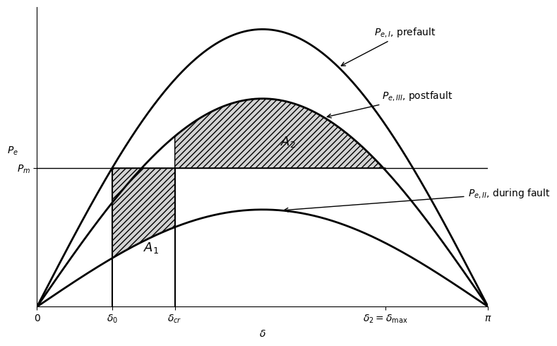

### Anvendelse av likearealkriteriet

Ved å anvende likearealkriteriet, $A_1 = A_2$, på tilfellet med kritisk utkoblingsvinkel kan vi skrive

$$ \int_{\delta_0}^{\delta_{cr}} \left( P_m - P_{\max II}\sin\delta \right) d\delta = \int_{\delta_{cr}}^{\delta_{\max}} \left( P_{\max III}\sin\delta - P_m \right) d\delta . $$

der

$$ \delta_{\max} = \pi - \sin^{-1}\!\left( \frac{P_m}{P_{\max III}} \right). $$

Integrasjon av begge sider gir

$$ \left[ P_m\delta + P_{\max II}\cos\delta \right]_{\delta_0}^{\delta_{cr}} + \left[ P_{\max III}\cos\delta + P_m\delta \right]_{\delta_{cr}}^{\delta_{\max}} = 0. $$

Ved innsetting av integrasjonsgrensene får vi

$$ P_m(\delta_{cr}-\delta_0) + P_{\max II} (\cos\delta_{cr}-\cos\delta_0) + P_m(\delta_{\max}-\delta_{cr}) + P_{\max III} (\cos\delta_{\max}-\cos\delta_{cr}) = 0. $$

De to leddene som inneholder $P_m$ kan slås sammen:

$$ P_m(\delta_{\max}-\delta_0) + P_{\max II} (\cos\delta_{cr}-\cos\delta_0) + P_{\max III} (\cos\delta_{\max}-\cos\delta_{cr}) = 0. $$

Samler vi leddene som inneholder $\cos\delta_{cr}$, får vi

$$ (P_{\max II}-P_{\max III}) \cos\delta_{cr} = -P_m(\delta_{\max}-\delta_0) + P_{\max II}\cos\delta_0 - P_{\max III}\cos\delta_{\max}. $$

Ved å multiplisere begge sider med $-1$ fås

$$ (P_{\max III}-P_{\max II}) \cos\delta_{cr} = P_m(\delta_{\max}-\delta_0) - P_{\max II}\cos\delta_0 + P_{\max III}\cos\delta_{\max}. $$

Dermed blir uttrykket for den kritiske utkoblingsvinkelen

$$ \boxed{ \cos\delta_{cr} = \frac{ P_m(\delta_{\max}-\delta_0) - P_{\max II}\cos\delta_0 + P_{\max III}\cos\delta_{\max} }{ P_{\max III}-P_{\max II} } } $$

Dette uttrykket benyttes for å beregne den kritiske utkoblingsvinkelen når den elektriske effekten under feilen ikke er null, altså når effekt-vinkelkurven under feilen fortsatt er gitt ved

$$ P_{e,II}=P_{\max II}\sin\delta. $$

```python
import numpy as np

Pm = 1         # Mechanical power

Pmax_II = 0.8     # During fault
Pmax_III = 1.5    # Postfault

delta0_deg = 28.44    # Initial load angle [deg]


# Convert to radians


delta0 = np.radians(delta0_deg)


# Maximum rotor angle
# δmax = π - asin(Pm/PmaxIII)


delta_max = np.pi - np.arcsin(Pm / Pmax_III)


# Critical clearing angle
# From Equation (?)


numerator = (
    Pm * (delta_max - delta0)
    - Pmax_II * np.cos(delta0)
    + Pmax_III * np.cos(delta_max)
)

denominator = Pmax_III - Pmax_II

delta_cr = np.arccos(numerator / denominator)

# --------------------------------------------------
# Results
# --------------------------------------------------

print(f"δ0   = {np.degrees(delta0):.2f}°")
print(f"δmax = {np.degrees(delta_max):.2f}°")
print(f"δcr  = {np.degrees(delta_cr):.2f}°")
```

```
δ0   = 28.44°
δmax = 138.19°
δcr  = 82.28°
```

# Euler-metoden

Gitt differensialligningen $\frac{dy}{dt}=f(t,y)$ med startbetingelsen $y(t_0)=y_0,$ kan Euler-metoden brukes til å beregne en tilnærmet løsning ved diskrete tidspunkter. For et tidssteg $h$ beregnes neste verdi som

$$ y_{n+1}=y_n+h\,f(t_n,y_n). $$

Tidspunktet oppdateres samtidig som

$$ t_{n+1}=t_n+h. $$

## Algoritme

1. Start med kjente verdier $t_0$ og $y_0$.
2. Beregn stigningstallet:

   $ f(t_n,y_n) $
3. Beregn neste verdi:

   $ y_{n+1}=y_n+h\,f(t_n,y_n) $
4. Gjenta prosessen for hvert tidssteg.

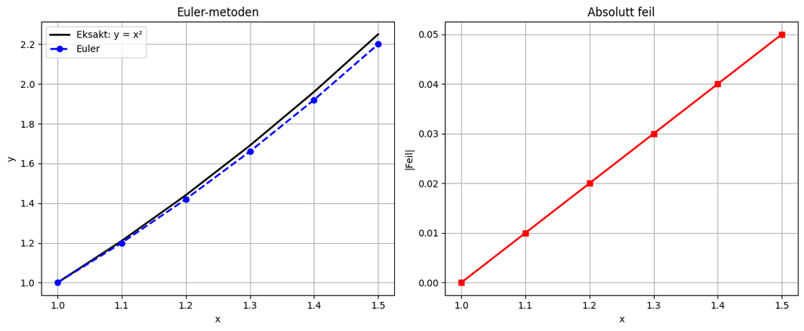

```
 n    x      Euler     Eksakt     Feil
----------------------------------------
 0   1.0     1.00      1.00     0.00
 1   1.1     1.20      1.21     0.01
 2   1.2     1.42      1.44     0.02
 3   1.3     1.66      1.69     0.03
 4   1.4     1.92      1.96     0.04
 5   1.5     2.20      2.25     0.05
```

###### Euler-metoden med eksakt verdi

Gitt

$$ \frac{dy}{dx}=2x $$

med startbetingelse

$$ y(1)=1 $$

og steglengde

$$ h=0.1. $$

Euler-formelen er

$$ y_{n+1}=y_n+h\,f(x_n) $$

der

$$ f(x)=2x. $$

| n | x_n | y_n (Euler) | Utregning | Eksakt verdi y(x_n)=x_n² | Feil |
| --- | --- | --- | --- | --- | --- |
| 0 | 1.0 | 1.00 | Startverdi | 1.00 | 0.00 |
| 1 | 1.1 | 1.20 | y₁ = 1.00 + 0.1·(2·1.0) = 1.20 | 1.21 | 0.01 |
| 2 | 1.2 | 1.42 | y₂ = 1.20 + 0.1·(2·1.1) = 1.42 | 1.44 | 0.02 |
| 3 | 1.3 | 1.66 | y₃ = 1.42 + 0.1·(2·1.2) = 1.66 | 1.69 | 0.03 |
| 4 | 1.4 | 1.92 | y₄ = 1.66 + 0.1·(2·1.3) = 1.92 | 1.96 | 0.04 |
| 5 | 1.5 | 2.20 | y₅ = 1.92 + 0.1·(2·1.4) = 2.20 | 2.25 | 0.05 |

### Resultat

Euler-metoden gir

$$ y(1.5)\approx 2.20 $$

mens den eksakte løsningen er

$$ y(1.5)=2.25. $$

Feilen blir

$$ e=2.25-2.20=0.05. $$

###### Euler-metoden for svingligningen

Svingligningen kan skrives som

$$ \frac{d^2\delta}{dt^2} = \frac{\pi f}{H}P_a. $$

Vi innfører vinkelhastigheten

$$ \omega=\frac{d\delta}{dt}, $$

slik at ligningen splittes i to førsteordens differensialligninger:

$$ \frac{d\delta}{dt} = \omega $$

og

$$ \frac{d\omega}{dt} = \frac{\pi f}{H}P_a. $$

## Oppdatering

Euler-metoden gir da oppdateringene

$$ \omega_{n+1} = \omega_n + h\frac{\pi f}{H}P_{a,n} $$

og

$$ \delta_{n+1} = \delta_n+h\omega_n. $$

Her er:

- $\delta_n$ rotorvinkelen ved tidspunkt $t_n$
- $\omega_n$ hastighetsavviket ved tidspunkt $t_n$
- $P_{a,n}$ akselerasjonseffekten ved tidspunkt $t_n$
- $h$ tidssteget

Disse ligningene brukes iterativt for å beregne rotorvinkel og hastighet gjennom en transient.

# Euler-metoden (punkt-for-punkt-metoden)

I denne metoden bestemmes endringen i rotorvinkelen over korte tidsintervaller.

Følgende antakelser gjøres:

1. Den akselererende effekten $\Delta P$ ved begynnelsen av et tidsintervall antas konstant fra midten av forrige intervall til midten av det aktuelle intervallet.
2. Vinkelhastigheten $\omega$ antas konstant gjennom hele tidsintervallet og beregnes for midtpunktet av intervallet.

## Endring i vinkelhastighet

Fra svingligningen

$$ M\frac{d^2\delta}{dt^2} = \Delta P $$

fås

$$ \frac{d^2\delta}{dt^2} = \frac{\Delta P}{M}. $$

Over tidsintervallet $\Delta t$ blir endringen i vinkelhastighet

$$ \omega_{n-\frac12} - \omega_{n-\frac32} = \frac{\Delta P_{n-1}}{M}\Delta t. $$

eller

$$ \Delta\omega_{n-\frac12} = \frac{\Delta P_{n-1}}{M}\Delta t. $$

Dette uttrykket brukes til å oppdatere rotorens hastighet fra ett halvsteg til det neste.

## Endring i rotorvinkel

Rotorvinkelens endring i intervallet fra tid $(n-2)$ til $(n-1)$ er

$$ \delta_{n-1}-\delta_{n-2} = \Delta\delta_{n-1}. $$

Siden $\omega_{n-\frac12}$ antas konstant gjennom intervallet,

$$ \omega_{n-\frac12} = \frac{\Delta\delta_{n-1}}{\Delta t}. $$

Dermed fås

$$ \Delta\delta_{n-1} = \omega_{n-\frac12}\Delta t $$

og

$$ \delta_{n-1} = \delta_{n-2} + \omega_{n-\frac12}\Delta t. $$

# Numerisk algoritme

For hvert tidssteg utføres følgende beregninger.

## 1. Beregn akselererende effekt

$$ \Delta P_n = P_m-P_e(\delta_n). $$

## 2. Oppdater vinkelhastigheten

$$ \omega_{n+\frac12} = \omega_{n-\frac12} + \frac{\Delta P_n}{M}\Delta t. $$

## 3. Oppdater rotorvinkelen

$$ \delta_{n+1} = \delta_n + \omega_{n+\frac12}\Delta t. $$

Over det $n$-te intervallet er endringen i rotorvinkelen

$$ \Delta\delta_n = \delta_n-\delta_{n-1} = \omega_{n-\frac12}\Delta t. $$

Tilsvarende er

$$ \Delta\delta_{n-1} = \delta_{n-1}-\delta_{n-2} = \omega_{n-\frac32}\Delta t. $$

Ved å subtrahere disse uttrykkene fås

$$ \Delta\delta_n-\Delta\delta_{n-1} = \Delta t \left( \omega_{n-\frac12} - \omega_{n-\frac32} \right). $$

Fra hastighetsoppdateringen har vi

$$ \omega_{n-\frac12} - \omega_{n-\frac32} = \frac{\Delta P_{n-1}}{M}\Delta t. $$

Innsetting gir

$$ \Delta\delta_n-\Delta\delta_{n-1} = \Delta t \left( \frac{\Delta P_{n-1}}{M}\Delta t \right) = \frac{\Delta P_{n-1}}{M} (\Delta t)^2. $$

Dermed fås den rekursive ligningen

$$ \boxed{ \Delta\delta_n = \Delta\delta_{n-1} + \frac{\Delta P_{n-1}}{M} (\Delta t)^2 } $$

Dette er grunnligningen for den klassiske punkt-for-punkt-metoden.

Når $\Delta\delta_n$ er funnet, oppdateres rotorvinkelen fra

$$ \boxed{ \delta_n = \delta_{n-1} + \Delta\delta_n } $$

# Fysisk betydning

Metoden følger den naturlige årsakskjeden i kraftsystemet

$$ (P_m-P_e) \rightarrow \text{akselerasjon} \rightarrow \omega \rightarrow \delta. $$

Den mekaniske og elektriske effektubalansen bestemmer rotorens akselerasjon. Akselerasjonen gir en endring i rotorhastigheten, og rotorhastigheten bestemmer deretter hvordan rotorvinkelen utvikler seg med tiden.

Ved å gjenta disse beregningene for små tidsintervaller kan den transiente rotorvinkelresponsen bestemmes numerisk uten å løse svingligningen analytisk.

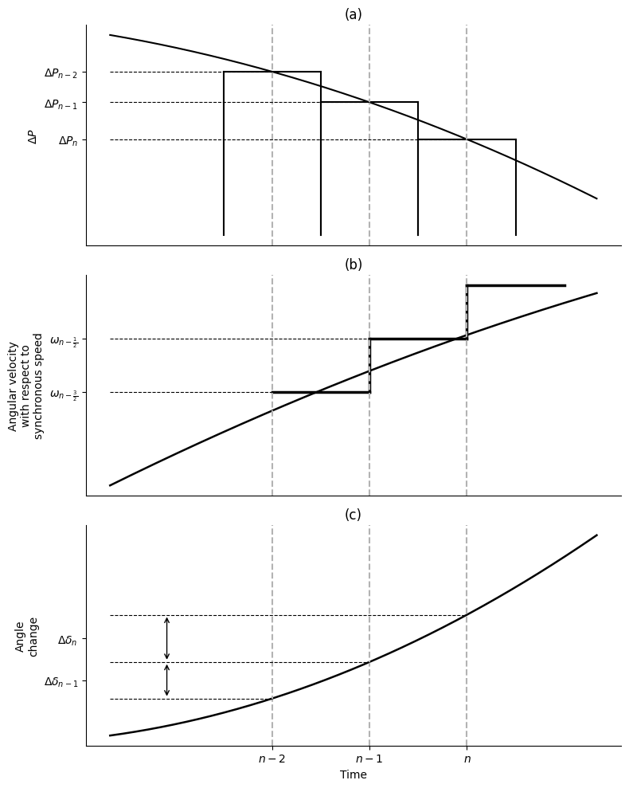

# Fremgangsmåte

- Bestem $\Delta_t$ (Vanligvis 0.05 s.)
- Finn M
- Beregn $\frac{(\Delta_t)^2}{M}$
- Finn normal driftsvinkel; $\delta_0 = sin^{-1}\big(\frac{P_m}{P_max}\big)$
- Finn $\Delta P$, rett etter feilen; $\Delta P = Pm - P_{max,feil} sin \delta_0$
- Den første verdien av den akselererende effekten refererer til midten av det foregående intervallet, mens den andre verdien refererer til midten av intervallet som analyseres: Bruk $\Delta P = \frac{\Delta P}{2}$
- Finn ny $\Delta\delta_n$:

$$\Delta\delta_n= \Delta\delta_{n-1}+\frac{(\Delta_t)^2}{M}\Delta P_{n-1}$$

#### Bestemmelse av $\delta_{cr}$ og $t_{cr}$ ved EAC og Stevenson

## Data

Før feil:

$$ P_e = 2.10\sin\delta $$

Under feil:

$$ P_e = 0.808\sin\delta $$

Etter feilutkobling:

$$ P_e = 1.50\sin\delta $$

Mekanisk effekt:

$$ P_m=1.0 $$

#### 1. Før-feil driftsvinkel

Før feilen gjelder

$$ P_m=P_{\max,\text{prefault}}\sin\delta_0 $$

slik at

$$ 1.0=2.10\sin\delta_0 $$

$$ \delta_0 = \sin^{-1}\!\left(\frac{1}{2.10}\right) $$

$$ \delta_0 = 28.44^\circ $$

###### 2. Ustabil post-fault-likevekt

Etter feilutkobling:

$$ P_e=1.50\sin\delta $$

og

$$ P_m=P_e. $$

Dermed

$$ 1.0=1.50\sin\delta $$

Den stabile løsningen er

$$ \delta_s = \sin^{-1}\!\left(\frac{1}{1.50}\right) = 41.81^\circ $$

Den ustabile løsningen er

$$ \delta_u = 180^\circ-41.81^\circ $$

$$ \delta_u = 138.19^\circ $$

###### 3. Likearealkriteriet

Kritisk stabilitet oppstår når

$$ A_1=A_2 $$

der

$$ A_1 = \int_{\delta_0}^{\delta_{cr}} (1-0.808\sin\delta)\,d\delta $$

og

$$ A_2 = \int_{\delta_{cr}}^{\delta_u} (1.50\sin\delta-1)\,d\delta. $$

Etter integrasjon:

$$ P_m(\delta_u-\delta_0) = 0.808(\cos\delta_0-\cos\delta_{cr}) + 1.50(\cos\delta_{cr}-\cos\delta_u) $$

Samle leddene med $\cos\delta_{cr}$:

$$ \cos\delta_{cr} = \frac{ P_m(\delta_u-\delta_0) - 0.808\cos\delta_0 + 1.50\cos\delta_u } {1.50-0.808} $$

# 4. Innsetting av tall

Konverter til radianer:

$$ \delta_0 = 28.44^\circ = 0.4964 $$

$$ \delta_u = 138.19^\circ = 2.4120 $$

Videre:

$$ \cos\delta_0 = 0.8793 $$

$$ \cos\delta_u = -0.7454 $$

Setter inn:

$$ \cos\delta_{cr} = \frac{ (2.4120-0.4964) - 0.808(0.8793) + 1.50(-0.7454) } {0.692} $$

$$ \cos\delta_{cr} = 0.128 $$

$$ \delta_{cr} = \cos^{-1}(0.128) $$

$$ \boxed{\delta_{cr}=82.6^\circ} $$

# 5. Stevenson-beregning

Gitt

$$ \Delta t=0.05\text{ s} $$

og

$$ \frac{(\Delta t)^2}{M} = 8.33 $$

Stevensons formler:

$$ \Delta(\Delta\delta) = 8.33\Delta P $$

$$ \Delta\delta_n = \Delta\delta_{n-1} + 8.33\Delta P_{n-1} $$

$$ \delta_n = \delta_{n-1} + \Delta\delta_n $$

## Stevenson-tabell

| t | δ | Pmax | Pe | ΔP | 8.33ΔP | Δδ |
| --- | --- | --- | --- | --- | --- | --- |
| 0.00 | 28.44 | 0.808 | 0.385 | 0.308 | 2.57 | 0.00 |
| 0.05 | 31.01 | 0.808 | 0.416 | 0.584 | 4.87 | 2.57 |
| 0.10 | 38.45 | 0.808 | 0.502 | 0.498 | 4.15 | 7.44 |
| 0.15 | 50.04 | 0.808 | 0.619 | 0.381 | 3.17 | 11.59 |
| 0.20 | 64.80 | 0.808 | 0.731 | 0.269 | 2.24 | 14.76 |
| 0.25 | 81.80 | 0.808 | 0.800 | 0.200 | 1.67 | 17.00 |
| 0.30 | 100.47 | 0.808 | 0.795 | 0.205 | 1.71 | 18.67 |

Første verdi er Stevenson-gjennomsnittet:

$$ \Delta P = \frac{ 0+ (1-0.808\sin28.44^\circ) }{2} = 0.308 $$

# 6. Kritisk klareringstid

Fra EAC:

$$ \delta_{cr}=82.6^\circ $$

Fra Stevenson-tabellen:

$$ \delta(0.25)=81.8^\circ $$

$$ \delta(0.30)=100.47^\circ $$

Interpolasjon gir

$$ t_{cr} = 0.25 + \frac{82.6-81.8} {100.47-81.8} \cdot0.05 $$

$$ t_{cr} = 0.252\text{ s} $$

# Resultat

$$ \boxed{\delta_{cr}=82.6^\circ} $$

$$ \boxed{t_{cr}=0.252\text{ s}} $$

Feilen må kobles ut før omtrent

$$ 0.25\text{ s} $$

for at generatoren skal forbli transient stabil.

## Beregning av de seks første tidsstegene

Startverdier:

$$ \delta_0 = 28.44^\circ $$

$$ \Delta\delta_0 = 0 $$

$$ \Delta P_0 = \frac{0+(1-0.808\sin28.44^\circ)}{2} = 0.308 $$

### Steg 1

$$ \Delta(\Delta\delta)_1 = 8.33(0.308) = 2.57^\circ $$

$$ \Delta\delta_1 = 0+2.57 = 2.57^\circ $$

$$ \delta_1 = 28.44+2.57 = 31.01^\circ $$

### Steg 2

$$ P_e = 0.808\sin(31.01^\circ) = 0.416 $$

$$ \Delta P = 1-0.416 = 0.584 $$

$$ \Delta(\Delta\delta)_2 = 8.33(0.584) = 4.87^\circ $$

$$ \Delta\delta_2 = 2.57+4.87 = 7.44^\circ $$

$$ \delta_2 = 31.01+7.44 = 38.45^\circ $$

### Steg 3

$$ P_e = 0.808\sin(38.45^\circ) = 0.502 $$

$$ \Delta P = 0.498 $$

$$ \Delta(\Delta\delta)_3 = 8.33(0.498) = 4.15^\circ $$

$$ \Delta\delta_3 = 7.44+4.15 = 11.59^\circ $$

$$ \delta_3 = 50.04^\circ $$

### Steg 4

$$ P_e = 0.808\sin(50.04^\circ) = 0.619 $$

$$ \Delta P = 0.381 $$

$$ \Delta(\Delta\delta)_4 = 8.33(0.381) = 3.17^\circ $$

$$ \Delta\delta_4 = 11.59+3.17 = 14.76^\circ $$

$$ \delta_4 = 64.80^\circ $$

### Steg 5

$$ P_e = 0.808\sin(64.80^\circ) = 0.731 $$

$$ \Delta P = 0.269 $$

$$ \Delta(\Delta\delta)_5 = 8.33(0.269) = 2.24^\circ $$

$$ \Delta\delta_5 = 14.76+2.24 = 17.00^\circ $$

$$ \delta_5 = 81.80^\circ $$

### Steg 6

$$ P_e = 0.808\sin(81.80^\circ) = 0.800 $$

$$ \Delta P = 0.200 $$

$$ \Delta(\Delta\delta)_6 = 8.33(0.200) = 1.67^\circ $$

$$ \Delta\delta_6 = 17.00+1.67 = 18.67^\circ $$

$$ \delta_6 = 100.47^\circ $$

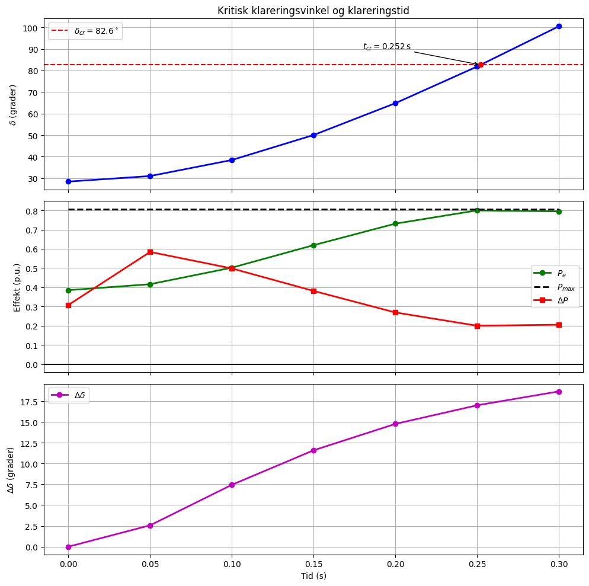

# Stevenson-beregning for stabilt tilfelle

Feilen kobles ut ved

$$ t_{\text{clear}}=0.20\text{ s} $$

som er mindre enn

$$ t_{cr}=0.252\text{ s}. $$

Dermed forventes stabil drift etter feilutkobling.

## Data

$$ P_m=1.0 $$

Under feil:

$$ P_e=0.808\sin\delta $$

Etter feilutkobling:

$$ P_e=1.50\sin\delta $$

$$ \frac{(\Delta t)^2}{M} = 8.33 $$

$$ \Delta t = 0.05\text{ s} $$

Startvinkel:

$$ \delta_0 = 28.44^\circ $$

## Stevenson-tabell

| t | δ | Pmax | Pe | ΔP | 8.33ΔP | Δδ |
| --- | --- | --- | --- | --- | --- | --- |
| 0.00 | 28.44 | 0.808 | 0.385 | 0.308 | 2.57 | 0.00 |
| 0.05 | 31.01 | 0.808 | 0.416 | 0.584 | 4.87 | 2.57 |
| 0.10 | 38.45 | 0.808 | 0.502 | 0.498 | 4.15 | 7.44 |
| 0.15 | 50.04 | 0.808 | 0.619 | 0.381 | 3.17 | 11.59 |
| 0.20 | 64.80 | 1.500 | 1.358 | -0.358 | -2.98 | 14.76 |
| 0.25 | 76.58 | 1.500 | 1.458 | -0.458 | -3.81 | 11.78 |
| 0.30 | 84.55 | 1.500 | 1.494 | -0.494 | -4.12 | 7.97 |
| 0.35 | 88.40 | 1.500 | 1.499 | -0.499 | -4.16 | 3.85 |
| 0.40 | 88.09 | 1.500 | 1.499 | -0.499 | -4.16 | -0.31 |

## Tolkning

Ved

$$ t=0.40\text{ s} $$

blir

$$ \Delta\delta <0. $$

Rotorhastigheten har da passert null.

Dette betyr at rotorvinkelen har nådd maksimum:

$$ \delta_{\max} \approx 88.4^\circ. $$

Siden

$$ \delta_{\max} < \delta_u = 138.2^\circ, $$

forblir systemet synkront.

Dermed er systemet transient stabilt.

# De seks første tidsstegene for stabilt tilfelle

Feilen kobles ut ved

$$ t_{\text{clear}}=0.20\text{ s} $$

Startverdier:

$$ \delta_0=28.44^\circ $$

$$ \Delta\delta_0=0 $$

$$ \Delta P_0 = \frac{0+(1-0.808\sin28.44^\circ)}{2} = 0.308 $$

## Steg 1

$$ \Delta(\Delta\delta)_1 = 8.33(0.308) = 2.57^\circ $$

$$ \Delta\delta_1 = 0+2.57 = 2.57^\circ $$

$$ \delta_1 = 28.44+2.57 = 31.01^\circ $$

## Steg 2

$$ P_e = 0.808\sin(31.01^\circ) = 0.416 $$

$$ \Delta P = 1-0.416 = 0.584 $$

$$ \Delta(\Delta\delta)_2 = 8.33(0.584) = 4.87^\circ $$

$$ \Delta\delta_2 = 2.57+4.87 = 7.44^\circ $$

$$ \delta_2 = 31.01+7.44 = 38.45^\circ $$

## Steg 3

$$ P_e = 0.808\sin(38.45^\circ) = 0.502 $$

$$ \Delta P = 0.498 $$

$$ \Delta(\Delta\delta)_3 = 8.33(0.498) = 4.15^\circ $$

$$ \Delta\delta_3 = 7.44+4.15 = 11.59^\circ $$

$$ \delta_3 = 38.45+11.59 = 50.04^\circ $$

## Steg 4

$$ P_e = 0.808\sin(50.04^\circ) = 0.619 $$

$$ \Delta P = 0.381 $$

$$ \Delta(\Delta\delta)_4 = 8.33(0.381) = 3.17^\circ $$

$$ \Delta\delta_4 = 11.59+3.17 = 14.76^\circ $$

$$ \delta_4 = 50.04+14.76 = 64.80^\circ $$

## Steg 5 (etter feilutkobling)

Nå endres

$$ P_{\max} $$

fra

$$ 0.808 $$

til

$$ 1.50. $$

$$ P_e = 1.50\sin(64.80^\circ) = 1.358 $$

$$ \Delta P = 1-1.358 = -0.358 $$

$$ \Delta(\Delta\delta)_5 = 8.33(-0.358) = -2.98^\circ $$

$$ \Delta\delta_5 = 14.76-2.98 = 11.78^\circ $$

$$ \delta_5 = 64.80+11.78 = 76.58^\circ $$

## Steg 6

$$ P_e = 1.50\sin(76.58^\circ) = 1.458 $$

$$ \Delta P = 1-1.458 = -0.458 $$

$$ \Delta(\Delta\delta)_6 = 8.33(-0.458) = -3.81^\circ $$

$$ \Delta\delta_6 = 11.78-3.81 = 7.97^\circ $$

$$ \delta_6 = 76.58+7.97 = 84.55^\circ $$

###### Stevenson-beregning for stabilt tilfelle ($t_{\text{clear}}=0.20$ s)

Data:

$$ P_m=1.0 $$

Under feil:

$$ P_e=0.808\sin\delta $$

Etter feilutkobling:

$$ P_e=1.50\sin\delta $$

$$ \frac{(\Delta t)^2}{M}=8.33 $$

$$ \Delta t=0.05\text{ s} $$

Startvinkel:

$$ \delta_0 = \sin^{-1}\!\left(\frac{1}{2.10}\right) = 28.44^\circ $$

Første Stevenson-verdi:

$$ \Delta P_0 = \frac{0+\left(1-0.808\sin28.44^\circ\right)}{2} = 0.308 $$

[output not shown]

* Første verdi:

$$ \Delta P_0 = \frac{0+\left(1-0.808\sin28.44^\circ\right)}{2} = 0.308 $$

### Viktig observasjon

Feilen kobles ut ved

$$ t=0.20\text{ s} $$

og da endres

$$ P_{\max} $$

fra

$$ 0.808 $$

til

$$ 1.50. $$

Derfor blir

$$ P_e>P_m $$

og

$$ \Delta P<0. $$

Vi ser da at

$$ \Delta\delta_4=14.76^\circ $$

$$ \Delta\delta_5=11.78^\circ $$

$$ \Delta\delta_6=7.97^\circ $$

Rotorhastigheten avtar kontinuerlig. Fortsetter beregningen noen få steg til, får vi

$$ \Delta\delta=0 $$

og deretter

$$ \Delta\delta<0, $$

slik at rotorvinkelen når et maksimum og begynner å avta igjen.

Dermed er systemet transient stabilt.

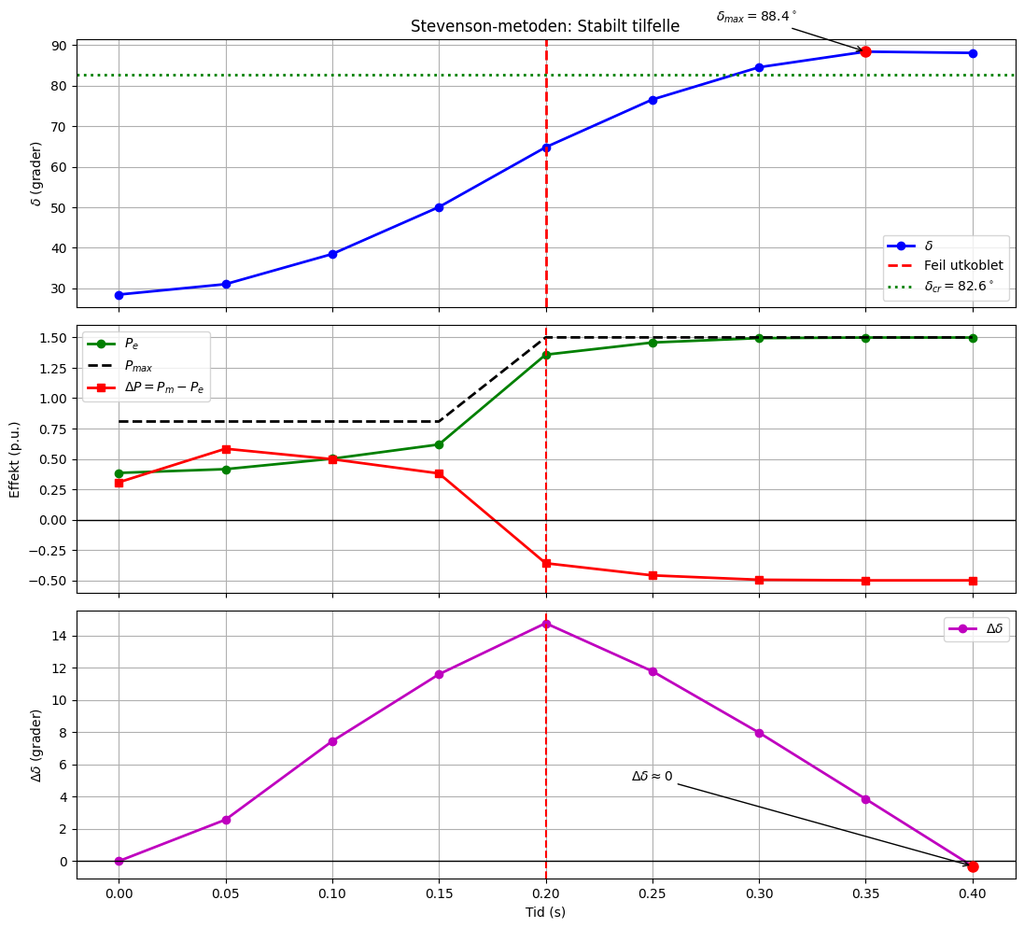